# Final Exam

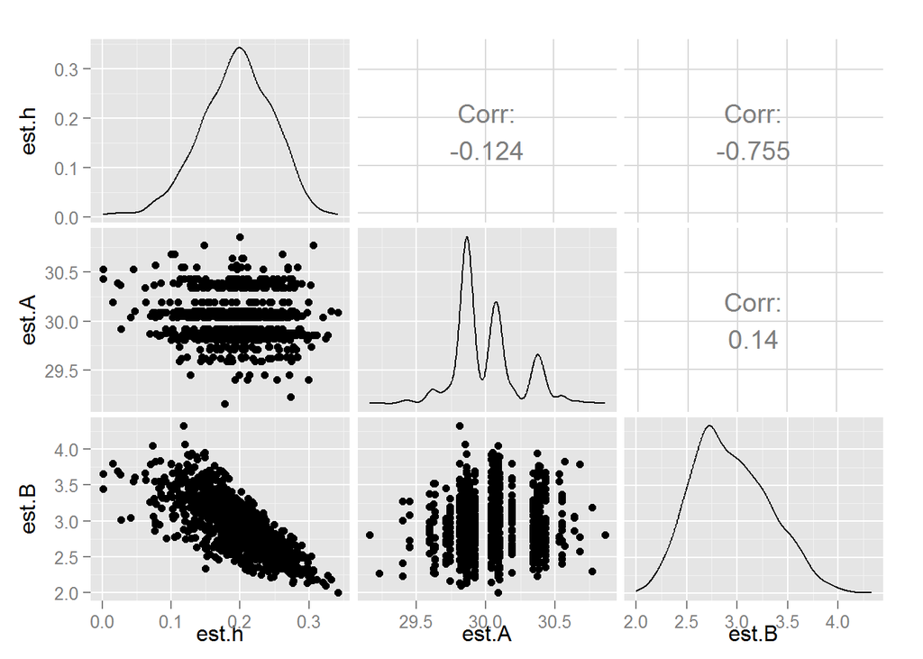

```r
#Pairs Plot
print(s$es.plt)
```

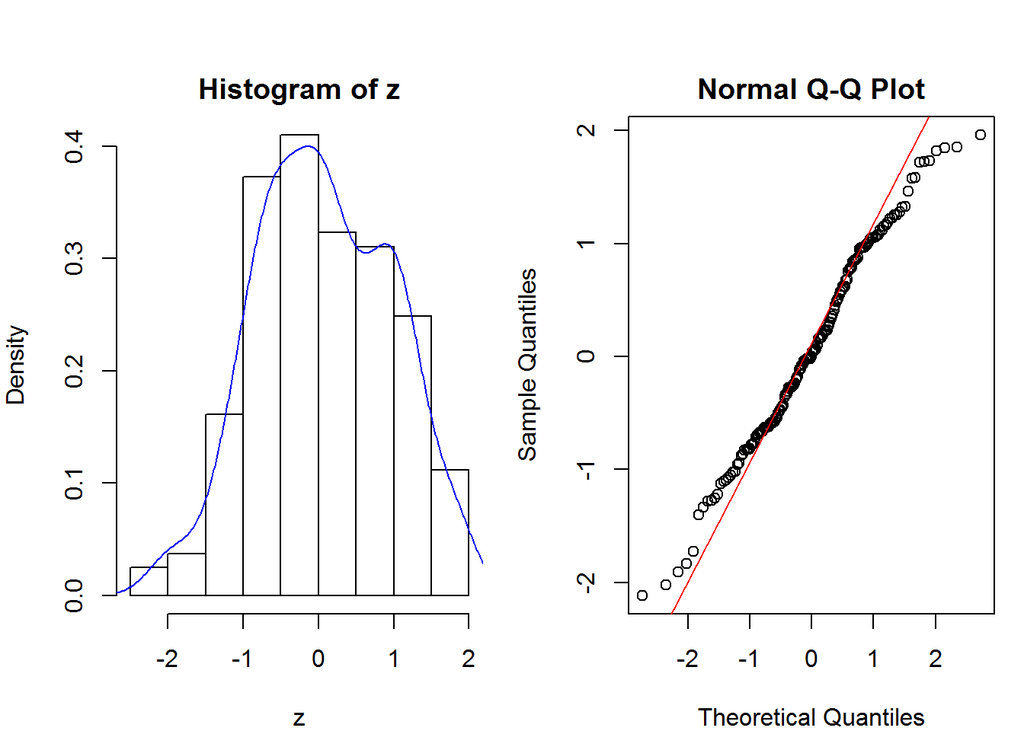

```r
HDistBackXform=function(h,A,B,data){
  ###################################
  #  This function will allow you to back solve for Z
  #  under any H-distribution transform
  #  the Values h, A, and B are the estimated values of
  #  the H-distribution parameters.  In this program
  #  data is a vector of data.
  ###################################

  n=length(data)
  #using Veleman's rule
  output=numeric(n)
  g=function(z){z*exp(h*z^2)-((x-A)/B)}
  # Begin loop on i where data[i] is the ith data value
  for(i in 1:n){
    x=data[i]
    obj=uniroot(g,interval=c(-6,6))
    output[i]=obj$root
  }
  return(output)
}

h<-normal.h$h
A<-normal.h$A
B<-normal.h$B

z<-HDistBackXform(h,A,B,b)
par(mfrow=c(1,2),mar = c(4, 4, 2, 1), oma = c(0, 0, 2, 0))
hist(z,prob=TRUE)
lines(density(z),col="blue")
qqnorm(z)
qqline(z,col="red")
```

```r
#Veleman's Rule for Pearson's GoF

noofbins=2*sqrt(length(z))
out<-gof.pearson(z,noofbins)
out
```

```
## $df
##                 bin bincount       prob expectedcount
## 1       (-Inf,-1.4]        6 0.04775222      7.688107
## 2      (-1.4,-1.13]        6 0.03979728      6.407362
## 3     (-1.13,-1.02]        6 0.02108262      3.394302
## 4    (-1.02,-0.825]        6 0.04636156      7.464211
## 5   (-0.825,-0.716]        6 0.03096361      4.985141
## 6   (-0.716,-0.632]        6 0.02626791      4.229134
## 7   (-0.632,-0.587]        6 0.01518388      2.444605
## 8   (-0.587,-0.484]        7 0.03626236      5.838240
## 9    (-0.484,-0.33]        7 0.05940056      9.563490
## 10   (-0.33,-0.251]        7 0.03285142      5.289078
## 11  (-0.251,-0.107]        7 0.06192364      9.969705
## 12 (-0.107,-0.0221]        7 0.03743175      6.026511
## 13 (-0.0221,0.0626]        7 0.03794367      6.108930
```

[output cut: 18 more lines]

```r
#9 Estimation of Mode


data = rnorm(100, 3, 2)

getGaussianMax = function(data){
  d = density(data, kernel="gaussian")
  index = which(d$y == max(d$y), arr.ind =TRUE)
  ans = d$x[index]
  return(ans)
}

calculatePseudoValues = function(data) {
  n = length(data)
  y.all = getGaussianMax(data)
  PV = numeric(n)
  for( i in 1:n) {
    yminusi = getGaussianMax(data[-i])
    PV[i] = n*y.all - (n-1)*yminusi
  }
  return(PV)
}

PVAll = calculatePseudoValues(data)
n = length(PVAll)


jackKnifeEstimate = mean(PVAll)
varJK = sum((PVAll - jackKnifeEstimate)^2)/(n*(n-1))
seJK = sqrt(varJK)

getbootstrapestimate = function(data, sims) {
  theta = numeric(sims)
  varTheta = numeric(sims)

  n = length(data)
  index = 1:n
  for (i in 1:sims){
    sampleindex= sample(index,n,replace=TRUE)
    theta[i] = mean(getGaussianMax(data[sampleindex]))
  }

  return(list(thetaBS = mean(theta), varBS = var(theta), seBS = sqrt(var(theta))))
}

BS = getbootstrapestimate(data, 100)$seBS

print(paste("The Mode is ",mean(PVAll) ))
```

```
## [1] "The Mode is  3.43317633321731"
```

```r
print(paste("The Standard Error of Jackknife Estimator",seJK))
```

```
## [1] "The Standard Error of Jackknife Estimator 0.225121552512169"
```

```r
print(paste("The Standard Error of Bootstrap Estimates",BS))
```

```
## [1] "The Standard Error of Bootstrap Estimates 0.680111858303124"
```

```r
q9data = rnorm(100, 3, 2)

getGausEstimate = function(data){
  d = density(data, kernel="gaussian")
  index = which(d$y == max(d$y), arr.ind =TRUE)
  ans = d$x[index]
  return(ans)
}

calculatePseudoValues = function(data) {
  n = length(data)
  yall = getGausEstimate(data)
  PV = numeric(n)
  for( i in 1:n) {
    yminusi = getGausEstimate(data[-i])
    PV[i] = n*yall - (n-1)*yminusi
  }
  return(PV)
}

# We first use jackknife
PVAll = calculatePseudoValues(q9data)
n = length(PVAll)
mean(PVAll)
```

```
## [1] 1.960042
```

```r
jackKnifeEstimate = mean(PVAll)
varJK = sum((PVAll - jackKnifeEstimate)^2)/(n*(n-1))
seJK = sqrt(varJK)
seJK
```

```
## [1] 0.2636036
```

```r
getbootstrapestimate = function(data, nsim) {
  theta = numeric(nsim)
  varTheta = numeric(nsim)

  n = length(data)
  index = 1:n
  for (i in 1:nsim){
    sampleindex= sample(index,n,replace=TRUE)
    theta[i] = mean(getGausEstimate(data[sampleindex]))
  }

  output = list(thetaBS = mean(theta), varBS = var(theta),
                seBS = sqrt(var(theta)))
  output
}
seBS = getbootstrapestimate(q9data, 100)$seBS
seBS
```

```
## [1] 0.5338059
```

1 The first step is to sort the values of x and divide the n points into 3 nearly equal groups 2 The summary points (median x, median y) will be estimated in outer groups R andL 3 We know slope = (yR-yL)/(xR-xL) , Intercept= median(yi-bxi)

Advantages of fitting RR line 1.Robustness 2.Easiest way to obtain linearity of data 3. It is Asymptotically efficient than OLS per step

Disadvantages of fitting RR line

1. Larger datasets are complex to operate using this
2. We dont arrive at a unique definite solution
3. It operates based on many iterations
1. Bootstrapping is resamplinng tchnique which helps when there is a doubt in the accutacy of usual distributional assumptions and asymptotic results 2 . Jackniffing is a special case of bootstrapping. It helps in variance and bias estimation 3 . Bootstrpping follows subsample data with replacement while the jackniffing resampling follows leave one out and calculate rest approach
2. In understanding variability and bias bootstrapping plays a major role as it is more accurate, the jackniffing helps in understanding bias of a point esstimator 5 Bootstrapping is more reliable when compared to jackniffing.

Given Number of scientific inventions for each year between 1860 and 1959

1. What distribution is appropriate for these count data

```r
library(e1071)
library(vcd)
invent <- c(5,3,0,2,0,3,2,3,6,1,2,1,2,1,3,3,3,5,2,4, 4,0,2,3,7,12,3,10,9,2,3,7,7,2,3,3,6,2,4,3, 5,2,2,4,0,4,2,5,2,3,3,6,5,8,3,6,6,0,5,2, 2,2,6,3,4,4,2,2,4,7,5,3,3,0,2,2,2,1,3,4, 2,2,1,1,1,2,1,4,4,3,2,1,4,1,1,1,0,0,2,0)
library(kequate)
#Tabulating the given
table(invent)
```

```
## invent
##  0  1  2  3  4  5  6  7  8  9 10 12
##  9 12 26 20 12  7  6  4  1  1  1  1
```

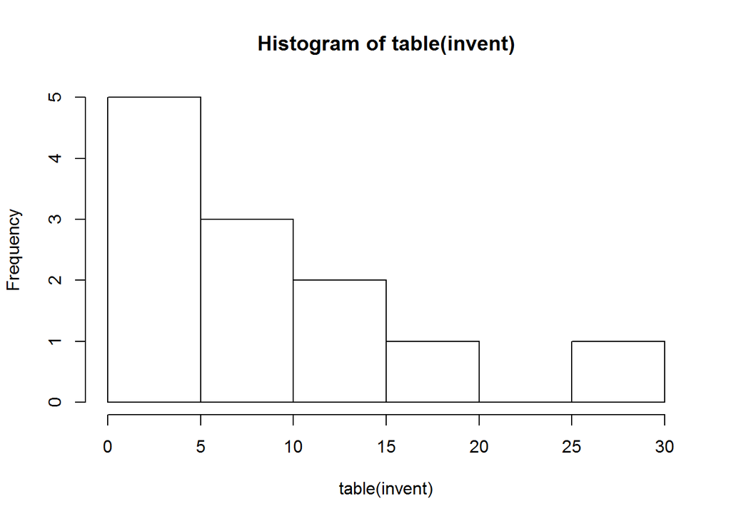

```r
#histogram

hist(table(invent))
```

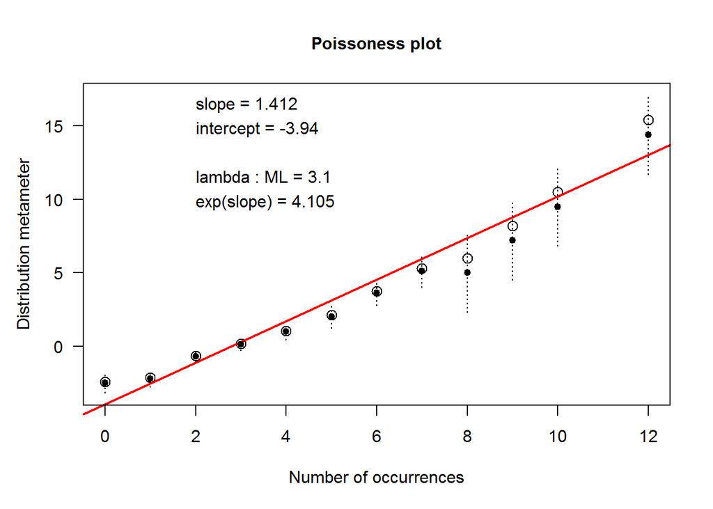

```r
#We see that it is quite similair ot poisson distribution, so we can say that poisson distribution might be appropriate for these count data


#Poisson Plot
distplot(table(invent))
```

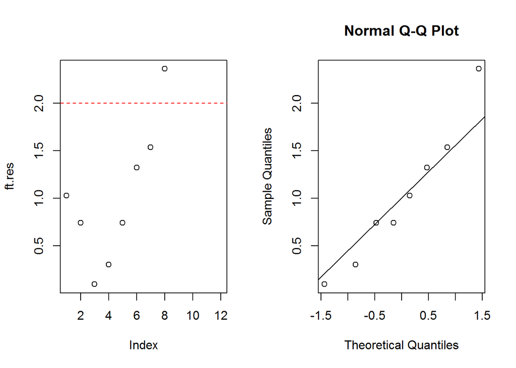

```r
#pLOT OF FREEMAN TUKEY RESIDUALS


ft.res<-FTres(table(invent), sapply(as.array(table(invent)),function(x){(1.142*x-3.94)}))
par(mfrow=c(1,2))
plot(ft.res)
abline(h=c(-2,0,2),lty=c(2,1,2),col=c(2,1,2))
qqnorm(ft.res)
qqline(ft.res)
```

```r
# SOme of the points can be seen to deviate from the plot
#Freeman  -Tukey residuals has a normal distribution
```

c Freeman tukey residuals are given by √(ni) +√(ni+1) - √(4mi+1) for a estimated frequency mi and observed frequency ni

The above residuals are used to stabilize the variance in the transformed data. QQ plot shows the normal distribution AND THE FREEMAN TUKEY variables are more clear.

```r
r1<-c(16,13.6,16.2,14.2,9.3,15.1,10.6,12,11.3,10.5,7.7,10.6)
r2<-c(30.4,27.3,32.4,24.1,27.3,21,19.2,22,19.4,14.9,11.4,18)
r3<-c(34.8,37.1,40.3,30.3,35,38.1,26.2,30.6,25.8,18.1,12.3,17.9)
r4<-c(37.2,41.8,42.1,34.6,38.8,34,30,31.8,27.9,18.9,13,17.9)
r5<-c(35.3,40.6,42.9,32.5,38.6,38.9,30.9,32.4,28.5,19.5,12.5,17.9)
r6<-c(39.2,41.4,43.9,35.4,37.5,39.6,32.4,31.1,28.1,22.2,13.7,18.9)
r7<-c(39.7,44.3,45.5,38.7,42.4,41.4,35.5,31.5,27.8,21.9,14.4,19.9)

df<-rbind(r1,r2,r3,r4,r5,r6,r7)
colnames(df)<-c(111,211,311,412,512,612,721,821,921,1022,1122,1222)
rownames(df)<-c(95,175,250,350,500,675,1000)
results<-medpolish(df)
```

```
## 1: 174.4
## 2: 162.35
## Final: 161.5375
```

```r
results
```

```
##
## Median Polish Results (Dataset: "df")
##
## Overall: 33.0125
##
## Row Effects:
##       95      175      250      350      500      675     1000
## -20.1375  -9.9625  -2.0500   0.0000   0.2125   1.3750   3.0000
##
## Column Effects:
##      111      211      311      412      512      612      721      821
##   3.8375   7.0125   9.3500   1.0500   4.2500   5.2125  -2.3250  -1.0500
##      921     1022     1122     1222
##  -5.1125 -12.8625 -20.0125 -15.1125
##
## Residuals:
##          111     211     311     412     512     612     721     821
## 95   -0.7125 -6.2875 -6.0250  0.2750 -7.8250 -2.9875  0.0500  0.1750
## 175   3.5125 -2.7625  0.0000  0.0000  0.0000 -7.2625 -1.5250  0.0000
## 250   0.0000 -0.8750 -0.0125 -1.7125 -0.2125  1.9250 -2.4375  0.6875
## 350   0.3500  1.7750 -0.2625  0.5375  1.5375 -4.2250 -0.6875 -0.1625
## 500  -1.7625  0.3625  0.3250 -1.7750  1.1250  0.4625  0.0000  0.2250
## 675   0.9750  0.0000  0.1625 -0.0375 -1.1375  0.0000  0.3375 -2.2375
## 1000 -0.1500  1.2750  0.1375  1.6375  2.1375  0.1750  1.8125 -3.4625
##          921    1022    1122    1222
## 95    3.5375 10.4875 14.8375 12.8375
## 175   1.4625  4.7125  8.3625 10.0625
## 250  -0.0500  0.0000  1.3500  2.0500
## 350   0.0000 -1.2500  0.0000  0.0000
## 500   0.3875 -0.8625 -0.7125 -0.2125
## 675  -1.1750  0.6750 -0.6750 -0.3750
## 1000 -3.1000 -1.2500 -1.6000 -1.0000
```

```
## 1: 174.4
## 2: 162.35
## Final: 161.5375
```

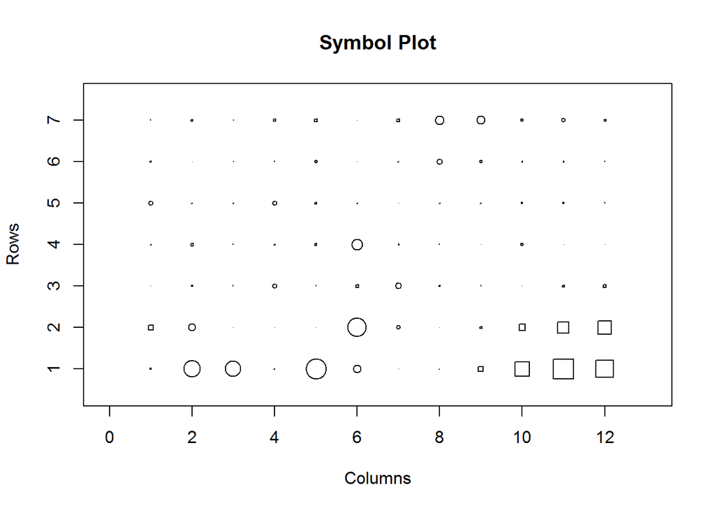

```r
symbolPlot<-function(mat){
  result<-medpolish(mat)
  res<-c(result$residuals)
  genNos<-expand.grid(1:7,1:12)
  plotvar<-cbind(genNos$Var2,genNos$Var1,res)
  pos<-plotvar[plotvar[,3]>=0,]
  max<-sum(abs(pos[,3]))
  symbols(pos[,1],pos[,2],squares = 3*(abs(pos[,3]/(max))),inches = FALSE,xlab="Columns",ylab="Rows",main="Symbol Plot")
  pos<-plotvar[plotvar[,3]<0,]
  symbols(pos[,1],pos[,2],circles = 3*(abs(pos[,3]/(max))),inches = FALSE,add = TRUE)
}



symbolPlot(df)
```

```r
#The plot shows the data clearly with better visualization of variability in data




#b


AnalogR<- 1-((sum(abs(results$residuals))) /(sum(abs(df-results$overall))))
print(paste("Variability Measure, Analog R Square :",AnalogR))
```

```
## [1] "Variability Measure, Analog R Square : 0.808064755680974"
```

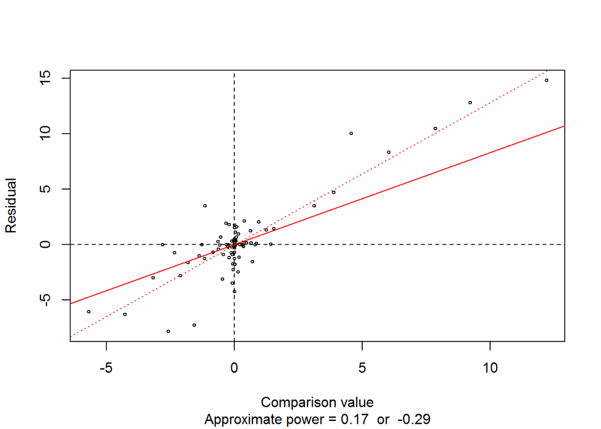

```r
#c


diag.MP <- function(fit){
  source("rrline.r")
  fit.comp <- matrix(fit$row,ncol=1) %*% matrix(fit$col,nrow=1)/fit$overall
  plot(fit.comp, fit$res,xlab="Comparison value",ylab="Residual",cex=0.5)
  abline(v=0,h=0,lty=2)
  ls <- lm(c(fit$res)~c(fit.comp))
  abline(ls,col="red",lty=3)
  rr <- run.rrline(fit.comp,fit$res,iter=10)
  abline(rr$a, rr$b, col="red")
  pwr1 <- 1 - rr$b
  pwr2 <- 1 - ls$coef[2]
  title("",paste("Approximate power =",format(round(pwr1,2))," or ", format(round(pwr2,2))))
}
diag.MP(results)
```

```r
#d

df.t <- df^(0.17)
results.t <- medpolish(df.t)
```

```
## 1: 1.76713
## 2: 1.487822
## Final: 1.47599
```

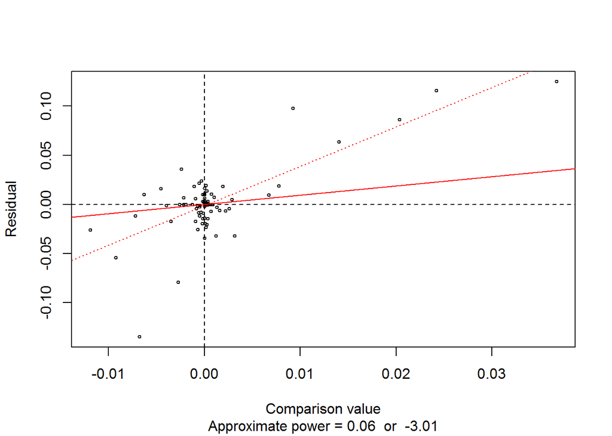

```r
diag.MP(results.t)
```

```r
analog_r2<- 1-((sum(abs(results.t$residuals))) /(sum(abs(df.t-results.t$overall))))
print(paste("Analog R square after Re-Expression : ",analog_r2))
```

```
## [1] "Analog R square after Re-Expression :  0.847646504570185"
```

```r
#e



stem(results.t$residuals,2)
```

```
##
##   The decimal point is 2 digit(s) to the left of the |
##
##   -12 | 5
##   -10 |
##    -8 |
##    -6 | 9
##    -4 | 4
##    -2 | 422663100
##    -0 | 774442298877644322111100
##     0 | 0000000000000011223335667790000014678899
##     2 | 146
##     4 |
##     6 | 4
##     8 | 68
##    10 | 6
##    12 | 5
```

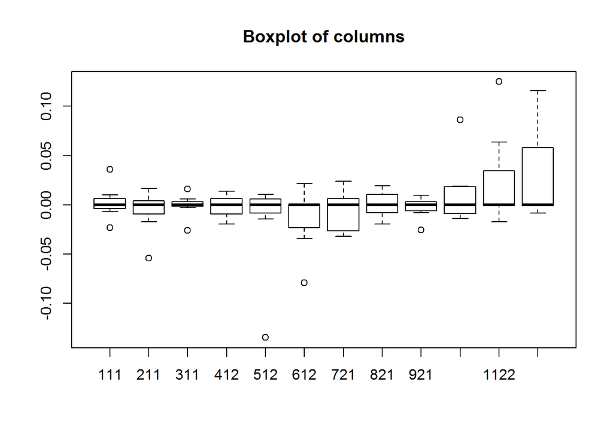

```r
# 5 is an outlier in the above stem leaf plot


#f
boxplot(results.t$residuals, main = "Boxplot of columns")
```

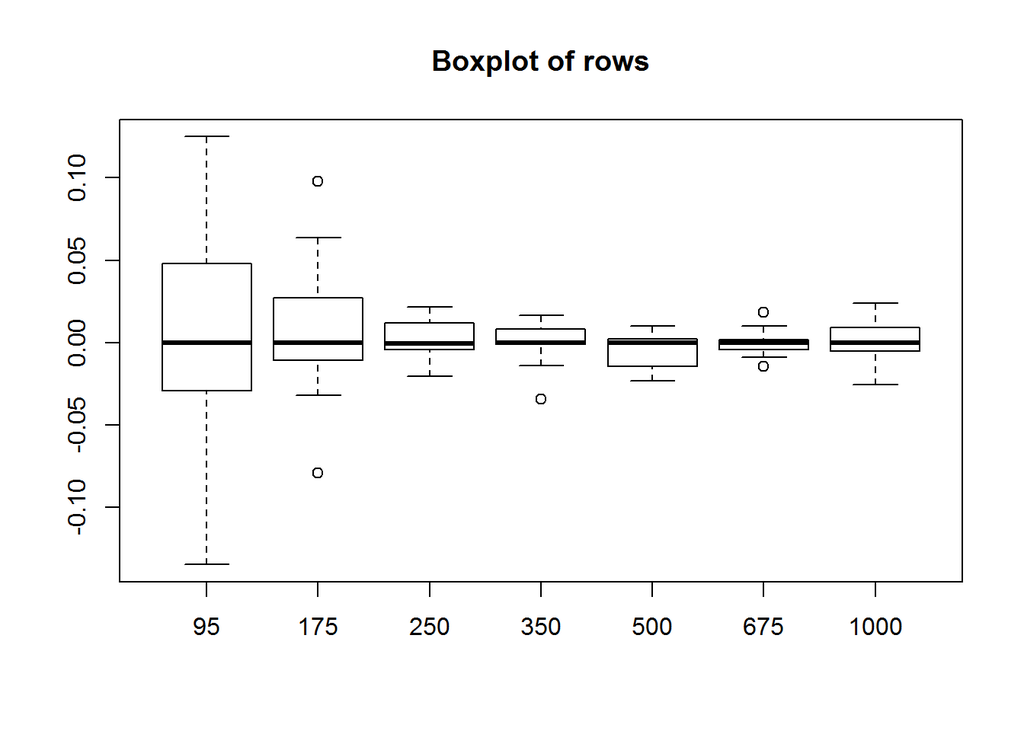

```r
boxplot(t(results.t$residuals), main = "Boxplot of rows")
```

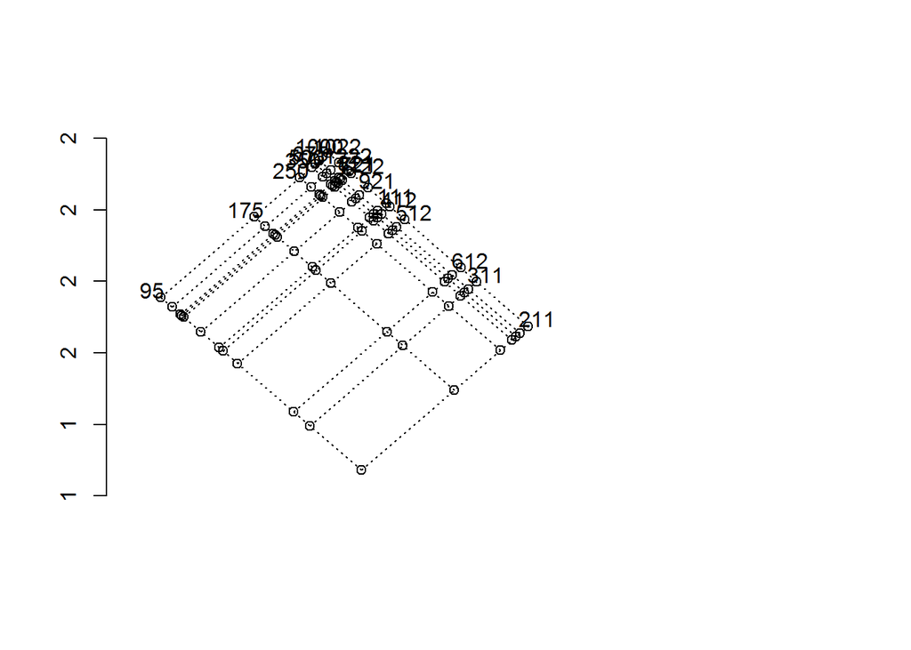

```r
#g

forgetitplot <- function(outmpol,outlim=0,...) {
  # outmpol is output of medpolish in library(eda) or library(stats)
  # be sure to assign dimnames to matrix being polished
  oldpar <- par()
  par(fig=c(0,.7,0,1))
  nc <- length(outmpol$col)
  nr <- length(outmpol$row)
  a <- rep(outmpol$row,nc)
  b <- rep(outmpol$col,rep(nr,nc))
  sqrt2 <- sqrt(2)
  ab <- cbind((a-b)/sqrt2,(a+b)/sqrt2)
  xrange <- range(ab[,1]) + c(-.1,.1)*(max(ab[,1])-min(ab[,1]))
  yrange <- range(ab[,2]) + c(-.1,.1)*(max(ab[,2])-min(ab[,2]))
  dx <- (xrange[2]-xrange[1])/50
  dy <- (yrange[2]-yrange[1])/50
  plot(ab[,1],ab[,2],axes=F,xlim=xrange,ylim=yrange,xlab="",ylab="",...)
  segments((min(a)-outmpol$col)/sqrt2, (min(a)+outmpol$col)/sqrt2,
           (max(a)-outmpol$col)/sqrt2, (max(a)+outmpol$col)/sqrt2,lty=3)
  segments((outmpol$row-min(b))/sqrt2, (outmpol$row+min(b))/sqrt2,
           (outmpol$row-max(b))/sqrt2, (outmpol$row+max(b))/sqrt2,lty=3)
  # segments((outmpol$row)/sqrt2-min(b), (outmpol$row)/sqrt2+min(b),
  # (outmpol$row)/sqrt2-max(b), (outmpol$row)/sqrt2+max(b),lty=3)
  yrowloc <- rep(max(b),nr)
  xrowloc <- outmpol$row
  # text((xrowloc-yrowloc)/sqrt2-dx,dy+(xrowloc+yrowloc)/sqrt2,format(1:nr))
  text((xrowloc-yrowloc)/sqrt2-dx,dy+(xrowloc+yrowloc)/sqrt2,
       names(sort(outmpol$row)))
  xcolloc <- rep(max(a),nc)
  ycolloc <- outmpol$col
  # text(dx+(xcolloc-ycolloc)/sqrt2,dy+(xcolloc+ycolloc)/sqrt2,format(1:nc))
  text(dx+(xcolloc-ycolloc)/sqrt2,dy+(xcolloc+ycolloc)/sqrt2,
       names(sort(outmpol$col)))
  ynames <- format(round(outmpol$overall + sqrt2*pretty(ab[,2])))
  axis(2,at=pretty(ab[,2]),labels=ynames)
  # add vertical lines when there is an outlier
  if(abs(outlim) > 1e-4) {
    out.index <- which(abs(outmpol$res) > outlim, arr.ind=T)
    # find (r,c) for outlier indices
    zz.x <- outmpol$row[out.index[,1]]
    zz.y <- outmpol$col[out.index[,2]]
    # outlier points at (zz.x-zz.y)/sqrt2, (zz.x+zz.y)/sqrt2
    # draw segment from here to end of residual
    segments((zz.x-zz.y)/sqrt2, (zz.x+zz.y)/sqrt2,
             (zz.x-zz.y)/sqrt2, (zz.x+zz.y)/sqrt2 + outmpol$res[out.index])
  }
  par <- oldpar
  invisible()
}
forgetitplot(results.t)
```

```r
# from the plot

#i Factor 95 is more infulential than the others
#ii  At plant 311 Co2 level 1000 had maximum effect



#h


#Bootstrap estimates



bootstrap <- function(mat, R)
{
  row.est <- matrix(0, nrow = R, ncol = nrow(mat))
  col.est <- matrix(0, nrow = R, ncol = ncol(mat))
  overall.est <- c()
  res <- medpolish(mat)
  for(i in 1:R)
  {
    sample.dat <- sample(mat, nrow(mat)*ncol(mat), replace = T)
    samp.mat <- matrix(sample.dat, nrow = nrow(mat), ncol = ncol(mat))
    bs <- medpolish(samp.mat)
    overall.est[i] <- bs$overall
    row.est[i,] <- bs$row
    col.est[i,] <- bs$col
  }
  r.est <- apply(row.est, 2, mean)
  c.est <- apply(col.est, 2, mean)

  rsd.est <- apply(row.est, 2, sd)
  csd.est <- apply(col.est, 2, sd)

  overall <- mean(overall.est)
  overallsd <- sd(overall.est)
  return(list(row = r.est, col = c.est, overall = overall, rowsd=rsd.est,colsd=csd.est,osd = overallsd ))
}

bs <- bootstrap(df, 1000)
```

```r
print(bs)
```

```
## $row
## [1] -0.3909438 -0.2707250 -0.3047375 -0.3128438 -0.3928875  0.1096812
## [7] -0.4524125
##
## $col
##  [1] -0.2085312 -0.1819562 -0.4244687 -0.3441187 -0.4650813 -0.2327562
##  [7] -0.0839375 -0.4536750 -0.1524937 -0.4388687 -0.4168938 -0.1898125
##
## $overall
## [1] 28.10316
##
## $rowsd
## [1] 4.547916 4.523209 4.501224 4.477641 4.574253 4.521811 4.488434
##
## $colsd
##  [1] 5.413394 5.475253 5.786246 5.661184 5.448890 5.536700 5.585822
##  [8] 5.535339 5.539726 5.748807 5.699131 5.588509
##
## $osd
## [1] 2.719414
```